# credit_card_churner_predictor

# Observations on Income Category count considering education level.

- Most graduates fall in <40k category
- Least number of graduates fall in the 120k+ category
- Most high schoolers fall in the <40k category
- Most uneducated falls in the <40k category.
- In the 120k+ category, graduates are more than other categories.
- In all the earning categories high schoolers are the second highest after graduates.

[output not shown]

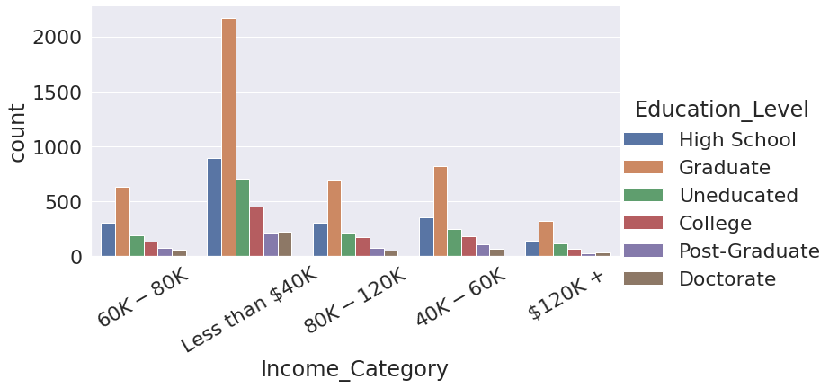

```python
sns.catplot(x="Income_Category",
            kind="count",
            hue="Education_Level",
            data=data,
            aspect=2)
plt.xticks(rotation=30)
```

# Observations on Card Category count considering gender.

- Blue is the most used card.
- More women use the blue card than men.
- More men use the Gold card than women.
- More men use the silver card than women.

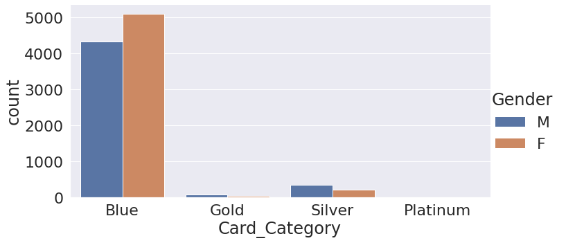

```python
sns.catplot(kind="count",
            x="Card_Category",
            hue="Gender",
            data=data,
            aspect=2)
```

# Observations on Card Category count considering income category.

- <40 k earners mostly use blue card
- 40 to 60 k earners second mostly use the blue card.
- Blue card is also popular among 120k+ earners among other cards.
- Silver is mostly used by <40k earners compared to other earning categories.
- Silver is second mostly used by 80-120k earners.

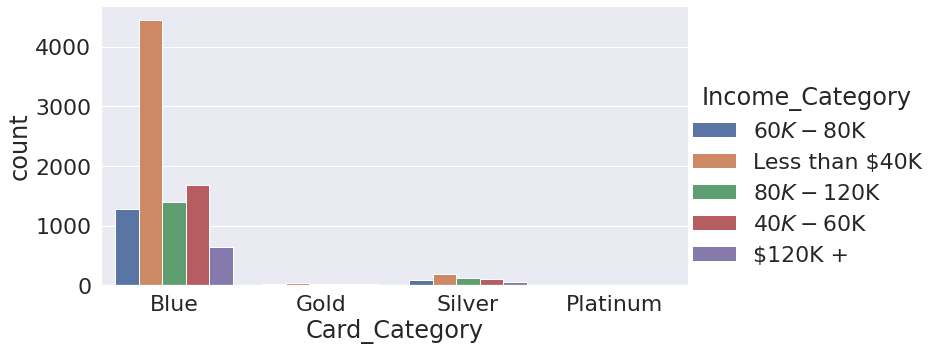

```python
sns.catplot(kind="count",
            x="Card_Category",
            hue="Income_Category",
            data=data,
            aspect=2)
```